# Tenth Week: Principal Component Analysis and Factor Analysis

PCA Stock, image, …

Milad Aghajohari 94105474

2018-05-20 03:17:09

> با استفاده از داده های OHLCV شرکت های تشکیل دهنده شاخص s&p500 و همچنین داده مربوط به شاخص های اقتصادی به سوالات زیر پاسخ دهید.

First we are going to load the data. The $stock\_data$ is data.frame which has 6 columns $Date$, $Open$, $Close$, $Volume$, $High$, $Low$.

```r
library(dplyr)
```

```r
library(tidyr)
library(highcharter)
library(readr)
library(stringr)
library(ggplot2)
```

```r
file_full_paths <- list.files(path="./class_data/stock_dfs", pattern="*", full.names=T, recursive=FALSE)
file_names <- list.files(path="./class_data/stock_dfs", pattern="*", full.names=F, recursive=FALSE)
strsplit(file_names, ".csv") %>% unlist() -> file_names
stocks_data <- data.frame()
for (i in 1:length(file_names)) {
  company_data <- read_csv(file_full_paths[i]) %>%
    select(Date, Open, Close, Volume, High, Low) %>% mutate(Symbol = file_names[i])
  rbind(stocks_data, company_data) -> stocks_data
}
```

۱. چه شرکتی رکورددار کسب بیشترین سود در بازه یکساله، دو ساله و پنج ساله می باشد؟ این سوال را برای بخش های مختلف مورد مطالعه قرار دهید و رکورددار را معرفی کنید. (برای این کار به ستون sector داده constituents مراجعه کنید.) برای هر دو قسمت نمودار سود ده شرکت و یا بخش برتر را رسم نمایید.

NOTE:We get every range so the start day can be every random day.

```r
stocks_data -> stoc_lag
stoc_lag$oneyear = lead(stoc_lag$Open, 365) - stoc_lag$Open
stoc_lag$twoyear = lead(stoc_lag$Open, 365*2) - stoc_lag$Open
stoc_lag$fiveyear = lead(stoc_lag$Open, 365*5) - stoc_lag$Open
constitute <- read_csv("./class_data/constituents.csv")
stoc_lag %>% .[complete.cases(.),] -> stoc_lag
stoc_lag %>% left_join(constitute) -> stoc_lag
stoc_lag %>% .[complete.cases(.),] -> stoc_lag
library(knitr)
stoc_lag %>% group_by(Sector) %>% arrange(-oneyear) %>%  select(Name, Sector, StartTime = Date, OneYearProfit = oneyear) %>% slice(1) %>% kable()
```

| Name | Sector | StartTime | OneYearProfit |
| --- | --- | --- | --- |
| Amazon.com Inc. | Consumer Discretionary | 2015-01-29 | 452.1300 |
| General Mills | Consumer Staples | 2016-03-28 | 277.5500 |
| Pioneer Natural Resources | Energy | 2012-12-31 | 122.1200 |
| CME Group Inc. | Financials | 2005-05-06 | 335.0400 |
| Bristol-Myers Squibb | Health Care | 2016-09-28 | 2344.1900 |
| Xylem Inc. | Industrials | 2015-07-24 | 429.8900 |
| Alphabet Inc Class C | Information Technology | 2012-07-12 | 547.8509 |
| CF Industries Holdings Inc | Materials | 2007-01-05 | 145.7300 |
| Equinix | Real Estate | 2015-01-29 | 172.9000 |
| CenturyLink Inc | Telecommunication Services | 2015-09-02 | 108.3700 |
| American Water Works Company Inc | Utilities | 2015-08-21 | 114.9102 |

```r
stoc_lag %>% group_by(Sector) %>% arrange(-twoyear) %>%  select(Name, Sector, StartTime = Date, TwoYearProfit = twoyear) %>% slice(1) %>% kable()
```

| Name | Sector | StartTime | TwoYearProfit |
| --- | --- | --- | --- |
| General Motors | Consumer Discretionary | 2016-12-30 | 512.7009 |
| General Mills | Consumer Staples | 2014-10-13 | 288.9700 |
| Pioneer Natural Resources | Energy | 2011-08-26 | 159.9500 |
| CME Group Inc. | Financials | 2005-01-25 | 512.9000 |
| Bristol-Myers Squibb | Health Care | 2016-06-20 | 2534.6699 |
| Xylem Inc. | Industrials | 2014-02-11 | 427.4900 |
| Alphabet Inc Class C | Information Technology | 2011-04-21 | 684.3111 |
| Sherwin-Williams | Materials | 2012-03-29 | 182.4600 |
| Macerich | Real Estate | 2016-02-17 | 238.3400 |
| CenturyLink Inc | Telecommunication Services | 2014-03-24 | 103.2300 |
| American Water Works Company Inc | Utilities | 2014-03-12 | 124.7602 |

```r
stoc_lag %>% group_by(Sector) %>% arrange(-fiveyear) %>% select(Name, Sector, StartTime = Date, FiveYearProfit = fiveyear) %>% slice(1) %>% kable()
```

| Name | Sector | StartTime | FiveYearProfit |
| --- | --- | --- | --- |
| Amazon.com Inc. | Consumer Discretionary | 2009-07-10 | 768.2700 |
| General Mills | Consumer Staples | 2010-06-29 | 289.7600 |
| Pioneer Natural Resources | Energy | 2007-03-26 | 193.0700 |
| CME Group Inc. | Financials | 2015-12-28 | 347.5500 |
| Bristol-Myers Squibb | Health Care | 2016-09-15 | 3769.6500 |
| TransDigm Group | Industrials | 2009-07-07 | 255.5000 |
| Mastercard Inc. | Information Technology | 2006-10-10 | 775.6900 |
| Sherwin-Williams | Materials | 2009-04-15 | 257.2300 |
| Macerich | Real Estate | 2016-12-13 | 581.2800 |
| Verizon Communications | Telecommunication Services | 2010-05-28 | 122.9001 |
| American Water Works Company Inc | Utilities | 2009-11-02 | 149.4102 |

۲. یک اعتقاد خرافی می گوید خرید سهام در روز سیزدهم ماه زیان آور است. این گزاره را مورد ارزیابی قرار دهید.

So We will test this againt the Null Hypothesis:No, There is no difference between the chance of Profit or Loss in 13th of the month.

```r
library(lubridate)
```

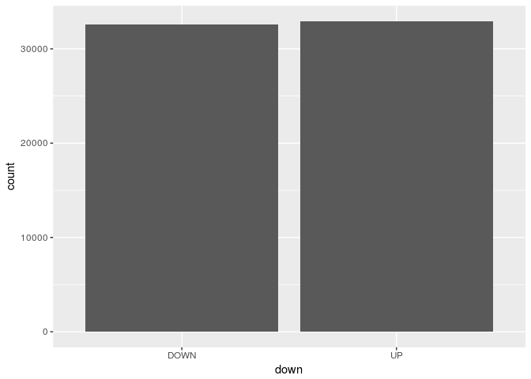

```r
stocks_data %>% filter(day(.$Date) == 13) %>% mutate(down = ifelse((Close >= Open), "UP", "DOWN")) -> stock_13
ggplot(stock_13)+geom_bar(aes(x = down))
```

```r
binom.test(sum(stock_13$down == "UP"), length(stock_13$down), 0.5, alternative = "less")
```

```
##
##  Exact binomial test
##
## data:  sum(stock_13$down == "UP") and length(stock_13$down)
## number of successes = 32926, number of trials = 65542, p-value =
## 0.8878
## alternative hypothesis: true probability of success is less than 0.5
## 95 percent confidence interval:
##  0.0000000 0.5055848
## sample estimates:
## probability of success
##              0.5023649
```

As you see the Null Hypothesis of No Difference is NOT Rejected in favor of Proabability of Success being less than 0.5. We can test this with another method too. We can test the mean of profit in 13th and other days agains each other.

```r
stocks_data %>% filter(day(.$Date) == 13) %>% mutate(profit = Close - Open) %>% .$profit-> the13
stocks_data %>% filter(day(.$Date) != 13) %>% mutate(profit = Close - Open) %>% .$profit-> not13
t.test(the13, not13, var.equal = F)
```

```
##
##  Welch Two Sample t-test
##
## data:  the13 and not13
## t = 1.1301, df = 70550, p-value = 0.2585
## alternative hypothesis: true difference in means is not equal to 0
## 95 percent confidence interval:
##  -0.006585324  0.024518595
## sample estimates:
##  mean of x  mean of y
## 0.02103613 0.01206949
```

So the the t.test DID NOT REJECT the null hypothesis of no difference between 13th and other days. SO this Khorafe is not TRUE at all.

۳. رکورد بیشترین گردش مالی در تاریخ بورس برای چه روزی بوده است و چرا!!!

```r
stocks_data %>% mutate(circ = abs(Close-Open)*Volume) %>% group_by(Date) %>% summarise(circ = sum(circ)) %>% arrange(-circ) %>% slice(1)
```

```
## # A tibble: 1 x 2
##   Date               circ
##   <date>            <dbl>
## 1 2008-10-10 25943598428.
```

It is the 10th October of 2008 which is the Day of the Global Financial Crisis In which Most of the Stocks went down So lots of people loose huge amounts of money. ***

۴. شاخص AAPL که نماد شرکت اپل است را در نظر بگیرید. با استفاده از رگرسیون خطی یک پیش کننده قیمت شروع (open price) بر اساس k روز قبل بسازید. بهترین انتخاب برای k چه مقداری است؟ دقت پیش بینی شما چقدر است؟

```r
stocks_data %>% filter(Symbol == "AAPL") -> applm
applm %>% select(-Close, -Date, -Symbol, -Volume) -> applm
library(h2o)
h2o.init()
```

[output not shown]

```r
for(i in 1:300){
  varname <- paste0(as.character(i),"back")
  applm %>% mutate( !!varname := lag(.$Open, i)) ->applm
}
applm %>% colnames()
```

```
##   [1] "Open"    "High"    "Low"     "1back"   "2back"   "3back"   "4back"
##   [8] "5back"   "6back"   "7back"   "8back"   "9back"   "10back"  "11back"
##  [15] "12back"  "13back"  "14back"  "15back"  "16back"  "17back"  "18back"
##  [22] "19back"  "20back"  "21back"  "22back"  "23back"  "24back"  "25back"
##  [29] "26back"  "27back"  "28back"  "29back"  "30back"  "31back"  "32back"
##  [36] "33back"  "34back"  "35back"  "36back"  "37back"  "38back"  "39back"
##  [43] "40back"  "41back"  "42back"  "43back"  "44back"  "45back"  "46back"
##  [50] "47back"  "48back"  "49back"  "50back"  "51back"  "52back"  "53back"
##  [57] "54back"  "55back"  "56back"  "57back"  "58back"  "59back"  "60back"
##  [64] "61back"  "62back"  "63back"  "64back"  "65back"  "66back"  "67back"
##  [71] "68back"  "69back"  "70back"  "71back"  "72back"  "73back"  "74back"
##  [78] "75back"  "76back"  "77back"  "78back"  "79back"  "80back"  "81back"
##  [85] "82back"  "83back"  "84back"  "85back"  "86back"  "87back"  "88back"
##  [92] "89back"  "90back"  "91back"  "92back"  "93back"  "94back"  "95back"
##  [99] "96back"  "97back"  "98back"  "99back"  "100back" "101back" "102back"
```

[output cut: 29 more lines]

```r
as.h2o(applm) -> happlm
n <- 20
x <- c()
for (i in 1:n){
  h2o.glm(y = "Open", x = paste0(1:i,"back") , training_frame = happlm, family="gaussian" ,nfolds = 5) -> hglm
  perf <- h2o.performance(hglm, happlm)
  c(x,h2o.mse(perf))->x
}
```

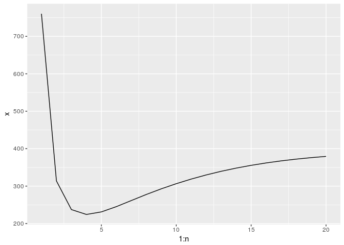

```r
which(x == min(x))->inmin
library(ggplot2)
ggplot()+geom_line(aes(x = 1:n, y = x))
```

```r
h2o.glm(y = "Open", x = paste0(1:inmin,"back") , training_frame = happlm, family="gaussian" ,nfolds = 5) -> hglm
summary(hglm)
```

```
## Model Details:
## ==============
##
## H2ORegressionModel: glm
## Model Key:  GLM_model_R_1526770039464_21
## GLM Model: summary
##     family     link                              regularization
## 1 gaussian identity Elastic Net (alpha = 0.5, lambda = 0.3465 )
##   number_of_predictors_total number_of_active_predictors
## 1                          4                           4
##   number_of_iterations training_frame
## 1                    1          applm
##
## H2ORegressionMetrics: glm
## ** Reported on training data. **
##
## MSE:  224.3246
## RMSE:  14.97747
## MAE:  7.554207
## RMSLE:  0.1543366
## Mean Residual Deviance :  224.3246
## R^2 :  0.9925551
## Null Deviance :128871686
## Null D.o.F. :4276
## Residual Deviance :959436.2
## Residual D.o.F. :4272
## AIC :35301.4
##
##
##
## H2ORegressionMetrics: glm
## ** Reported on cross-validation data. **
## ** 5-fold cross-validation on training data (Metrics computed for combined holdout predictions) **
##
## MSE:  256.1693
## RMSE:  16.00529
## MAE:  8.753072
## RMSLE:  0.1799666
## Mean Residual Deviance :  256.1693
## R^2 :  0.9914982
```

[output cut: 27 more lines]

```
## Scoring History:
##             timestamp   duration iterations negative_log_likelihood
## 1 2018-05-20 03:17:44  0.000 sec          0         128871686.74886
##     objective
## 1 30131.32727
##
## Variable Importances: (Extract with `h2o.varimp`)
## =================================================
##
## Standardized Coefficient Magnitudes: standardized coefficient magnitudes
##   names coefficients sign
## 1 1back    44.049638  POS
## 2 2back    41.844992  POS
## 3 3back    40.371153  POS
## 4 4back    39.675877  POS
```

۵. بر روی داده های قیمت شروع شرکت ها الگوریتم pca را اعمال کنید. نمودار تجمعی درصد واریانس بیان شده در مولفه ها را رسم کنید. سه مولفه اول چند درصد از واریانس را تبیین می کند؟

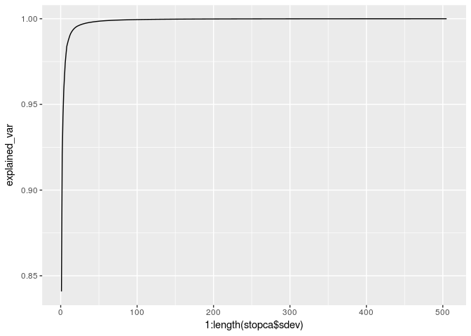

```r
stocks_data %>% select(Date, Open, Symbol) %>% spread(key = Symbol, value = Open)->stoca
colMeans(stoca[,-1],na.rm = T)->stoca_colm
stoca <- stoca[,colSums(is.na(stoca))<nrow(stoca)]
for(i in 2:ncol(stoca)){
  mean(unlist(stoca[,i]), na.rm = T) -> stoca[which(is.na(stoca[,i])),i]
}
prcomp(stoca[,-1], center = T)-> stopca
cumsum(stopca$sdev^2)/sum(stopca$sdev^2)->explained_var
ggplot()+geom_line(aes(x = 1:length(stopca$sdev), y = explained_var))
```

```r
explained_var[3]
```

```
## [1] 0.9428184
```

The First plot is the aggregate sum of the explained variation in y and x is the number of principal components takens into account in each. As you can see the first 3 Principal Components Explain 0.9428184 percent of the variance.

۶. برای هر نماد اطلاعات بخش مربوطه را از داده constituents استخراج نمایید. برای هر بخش میانگین روزانه قیمت شروع شرکت های آن را محاسبه کنید. سپس با استفاده از میانگین به دست آمده داده ایی با چند ستون که هر ستون یک بخش و هر سطر یک روز هست بسازید. داده مربوط را با داده شاخص های اقتصادی ادغام کنید. بر روی این داده pca بزنید و نمودار biplot آن را تفسیر کنید.

```r
constitute <- read_csv("./class_data/constituents.csv")
stocks_data %>% left_join(constitute) -> stoc_com
stoc_com %>% .[complete.cases(.),]->stoc_cam
stoc_com %>% group_by(Date, Sector) %>% summarise(Open = mean(Open, na.rm = T)) %>% ungroup()-> stoc_mean
stoc_mean %>% spread(Sector, Open) -> stoc_mean
indices <- read_csv("./class_data/indexes.csv")
stoc_mean %>% left_join(indices) -> stoc
```

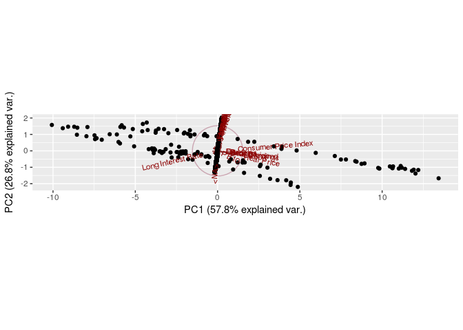

```r
colMeans(stoc[,-1],na.rm = T)->stoc_colm
for(i in 2:ncol(stoc)){
  as.numeric(stoc_colm[i-1]) -> stoc[which(is.na(stoc[,i])),i]
}
n <- nrow(stoc)
#stoc[sample(1:n, 30),] -> stoc_sam
stoc -> stoc_sam
prcomp(stoc_sam[,-1], center = T)->stopca
library(ggbiplot)
stopca %>% ggbiplot(obs.scale = 0.00001, var.scale = 0.1, ellipse = TRUE, circle = TRUE)
```

```r
library(factoextra)
```

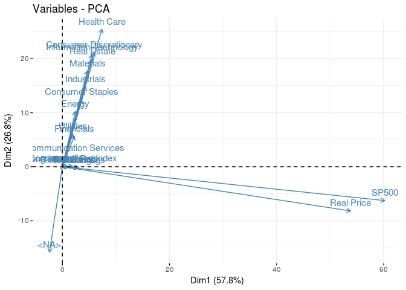

```r
fviz_pca_var(stopca, col.var = "steelblue")
```

As you can see Most of the Sectors vectors are in the same direction. It means that the go in the same directions most of the times. And the Real Price And Sp 500 are in the same direction which means they are correlated with each other but they are not correlated with other variables. ***

۷. روی همه اطلاعات (OHLCV) سهام اپل الگوریتم PCA را اعمال کنید. سپس از مولفه اول برای پیش بینی قیمت شروع سهام در روز آینده استفاده کنید. به سوالات سوال ۴ پاسخ دهید. آیا استفاده از مولفه اول نتیجه بهتری نسبت به داده open price برای پیش بینی قیمت دارد؟

```r
stocks_data %>% filter(Symbol == "AAPL")  -> apple_stoc
apple_stoc %>% select(-Date,-Symbol) %>% prcomp() -> apca
apple_stoc$PC1 <- apca$x[,"PC1"]
apple_stoc$TOpen <- lead(apple_stoc$Open)
library(h2o)
h2o.init()
```

[output not shown]

```r
as.h2o(apple_stoc) -> happle_stoc
h2o.glm(y = "TOpen", x = paste0("PC1") , training_frame = happle_stoc, family="gaussian" ,nfolds = 5) -> hglm
perf <- h2o.performance(hglm, happle_stoc)
h2o.mse(perf)
```

```
## [1] 30130.19
```

۸. نمودار سود نسبی شاخص s&p500 را رسم کنید. آیا توزیع سود نرمال است؟(از داده indexes استفاده کنید.) با استفاده از ده مولفه اول سوال پنج آیا می توانید سود و ضرر شاخص s&p500 را برای روز آينده پیش بینی کنید؟ از یک مدل رگرسیون لاجستیک استفاده کنید. درصد خطای پیش بینی را به دست آورید.

```r
indices <- read_csv("class_data/indexes.csv")
(lead(indices$SP500) - indices$SP500)/indices$SP500 -> sp_relative
shapiro.test(sp_relative)
```

```
##
##  Shapiro-Wilk normality test
##
## data:  sp_relative
## W = 0.89829, p-value < 2.2e-16
```

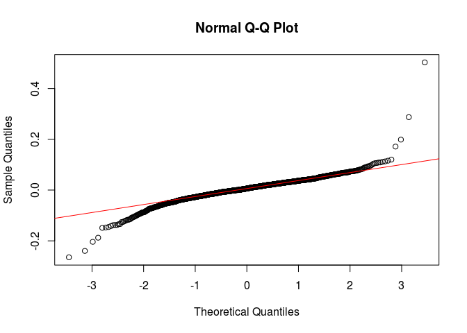

```r
qqnorm(sp_relative);qqline(sp_relative, col = 2)
```

```r
indices$SPR <- (sp_relative)>0

stoca %>% left_join(indices %>% select(Date, SPR)) -> stoca
data.frame(stopca$x[,1:10], SPR = stoca$SPR) -> spcasp
spcasp %>% .[complete.cases(.),] -> spcasp
library(h2o)
h2o.init()
```

[output not shown]

```r
as.h2o(spcasp) -> hspcasp
h2o.glm(y = "SPR", x = setdiff(colnames(spcasp),"SPR"), training_frame = hspcasp, family="binomial" ,nfolds = 5) -> hglm
summary(hglm)
```

```
## Model Details:
## ==============
##
## H2OBinomialModel: glm
## Model Key:  GLM_model_R_1526770039464_23
## GLM Model: summary
##     family  link                               regularization
## 1 binomial logit Elastic Net (alpha = 0.5, lambda = 0.01582 )
##   number_of_predictors_total number_of_active_predictors
## 1                         10                           8
##   number_of_iterations training_frame
## 1                    3         spcasp
##
## H2OBinomialMetrics: glm
## ** Reported on training data. **
##
## MSE:  0.2107647
## RMSE:  0.4590912
## LogLoss:  0.6109682
## Mean Per-Class Error:  0.4482184
## AUC:  0.6921302
## Gini:  0.3842604
## R^2:  0.08692037
## Residual Deviance:  158.8517
## AIC:  176.8517
##
## Confusion Matrix (vertical: actual; across: predicted) for F1-optimal threshold:
##        FALSE TRUE    Error     Rate
## FALSE      6   41 0.872340   =41/47
## TRUE       2   81 0.024096    =2/83
## Totals     8  122 0.330769  =43/130
##
## Maximum Metrics: Maximum metrics at their respective thresholds
##                         metric threshold    value idx
## 1                       max f1  0.437391 0.790244 121
## 2                       max f2  0.318307 0.898268 129
## 3                 max f0point5  0.628611 0.796345  74
## 4                 max accuracy  0.628611 0.723077  74
## 5                max precision  0.884065 1.000000   0
## 6                   max recall  0.318307 1.000000 129
```

[output cut: 83 more lines]

```
## Variable Importances: (Extract with `h2o.varimp`)
## =================================================
##
## Standardized Coefficient Magnitudes: standardized coefficient magnitudes
##    names coefficients sign
## 1    PC9     0.273917  POS
## 2    PC6     0.261937  POS
## 3    PC8     0.206226  NEG
## 4    PC4     0.156176  POS
## 5    PC5     0.131848  NEG
## 6    PC1     0.090418  NEG
## 7    PC3     0.066020  NEG
## 8    PC7     0.023852  POS
## 9    PC2     0.000000  POS
## 10  PC10     0.000000  POS
```

۹. عکسی که در ابتدای متن آمده را در نظر بگیرید. با استفاده از pca عکس را فشرده کنید. سپس نمودار حجم عکس فشرده بر حسب تعداد مولفه اصلی را رسم کنید. بهترین انتخاب برای انتخاب تعداد مولفه ها در جهت فشرده سازی چه عددی است؟

```r
library(EBImage)
pic = flip(readImage("images/stock.jpg"))
 red.weigth   = .2989
  green.weigth = .587
  blue.weigth  = 0.114
  img = red.weigth * imageData(pic)[,,1] +
    green.weigth * imageData(pic)[,,2] + blue.weigth  * imageData(pic)[,,3]
  pca.img = prcomp(img, scale=TRUE)

pic_compress<-function(pic, n){
  chosen_components <- 1:n
  feature_vector <- pca.img$rotation[,chosen_components]
  compact_data <- t(feature_vector) %*% t(img)
  approx.img <- t(feature_vector %*% compact_data)
  return(approx.img)
}

lapply(1:412, function(x){
  pic_compress(pic, x)->pic_zip
  writeImage(flip(pic_zip), paste0("./images/image",str_pad(as.character(x),3,"left","0"),".jpg"))
}
)
```

[output not shown]

[output cut: 1180 more lines]

[output not shown]

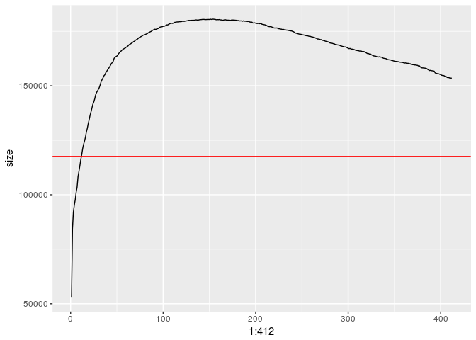

```r
image_names <- list.files(path="./images", pattern="image", full.names=T, recursive=FALSE)
sort(image_names)->image_names
file.info(image_names)$size->size
file.info("./images/stock.jpg")$size->org.size
library(ggplot2)
ggplot()+geom_line(aes(x = 1:412, y = size))+geom_abline(slope = 0, intercept = org.size, color = "red")
```

```r
which(size < org.size)
```

```
##  [1]  1  2  3  4  5  6  7  8  9 10 11
```

As you can see we should use less than 11 components or we are actually just using the same space or even more.

```r
red.weigth   = .2989
green.weigth = .587
blue.weigth  = 0.114
img = red.weigth * imageData(pic)[,,1] +
  green.weigth * imageData(pic)[,,2] + blue.weigth  * imageData(pic)[,,3]
pca.img = prcomp(img, scale=TRUE)
cumsum(pca.img$sdev^2)/sum(pca.img$sdev^2) -> ve
min(which(ve > 0.65))
```

```
## [1] 6
```

So in Order to save $65$percent of the variance. If we use more than this we are actually occupying more space than the original photo or the space is just very near the real space but the amount of variance explained is not that much.

۱۰. پنج ایده جالبی که روی داده های مالی بالا می توانستیم پیاده کنیم را بیان کنید. (ایده کافی است نیازی به محاسبه بر روی داده نیست.)

# Idea 1:

Which Sector has the most variance in relative changes in Value?Which company has the most variance in growth? Which company has the least(I suppouse it would be the thechnological companies but who knows?)

# Idea 2:

Can you build a linear model to guess SP satistic based on the other statistics?

# Idea 3:

Are these statistics (in indexes.csv file )correlated With Each other?

# Idea 4:

Plot the value of mean sector shares over various sectors over years.(I have done this actually, take a look:)

```r
stocks_data %>% left_join(constitute) -> stoc_sec
stoc_sec %>% .[complete.cases(.),]->stoc_sec
stoc_sec %>% mutate(year = lubridate::year(Date))  -> stoc_sec
stoc_sec %>% group_by(Sector,year) %>% arrange(-Open) %>% slice(1:(n()/10))%>% summarise(value = mean(Open)) %>% hchart(type = "line", hcaes(group = Sector,x = year, y = value))
```

[output not shown]

# Idea 5:

Which Sector obeys this rule more than the others : Richs get richer and Poor get more poor? (You can plot the sum of the values of the first 10 percent companies againts the whole. It is not that perfect and may be a little wrong but I think this can be a good attack to this problem)

```r
detach("package:h2o", unload= T)
stocks_data %>% left_join(constitute) -> stoc_sec
stoc_sec %>% .[complete.cases(.),]->stoc_sec
stoc_sec %>% mutate(year = lubridate::year(Date))  -> stoc_sec
stoc_sec %>% group_by(Sector,year) %>% arrange(-Open) %>% slice(1:(n()/10))%>% summarise(top10 = sum(Open)) -> top10
stoc_sec %>% group_by(Sector,year) %>% summarise(all = sum(Open)) -> all
all %>% full_join(top10) -> stoc_all
stoc_all %>% mutate(percent_in_top_10 = top10/all) -> stoc_all
stoc_all %>% hchart(type = "line", hcaes(group = Sector,x = year, y = percent_in_top_10))
```

[output not shown]